# CARDIOTOCOGRAPHY Data analysis to find out the Fetal status

#### Fetal status defined as (Normal/Suspect/ Pathologic) - It’s a Categorical prediction with Nominal in nature

#### Methodology Used:

###### 1. Stepwise Regression using StepAIC to reduce the no. of independent variable

###### 2. Multinomial Logistic Regression - Which helps to predict nominal output variables

###### 3. Decision Tree Using rpart & Validation using test dataset & used Party package to improvise the visualization of tree

###### 4. Bagging & Random Forest Approach to improve the model

### 1. Stepwise Regression using StepAIC function to reduce the no. of independent variable

##### Metrics considered for NSP classification

1. LB Baseline value
2. AC accelerations
3. FM foetal movement
4. UC uterine contractions
5. DL light decelerations
6. DS severe decelerations
7. DP Prolonged decelerations
8. ASTV percentage of time with abnormal short term variability
9. MSTV mean value of short term variability
10. ALTV percentage of time with abnormal long term variability
11. MLTV mean value of long term variability
12. Width histogram width
13. Min low freq. of the histogram
14. Max high freq. of the histogram
15. Nmax number of histogram peaks
16. Nzeros number of histogram zeros
17. Mode histogram mode
18. Mean histogram mean
19. Median histogram median
20. Variance histogram variance
21. Tendency histogram tendency: -1=left asymmetric; 0=symmetric; 1=right asymmetric
22. CLASS FHR pattern class code (1 to 10)
23. NSP Normal=1; Suspect=2; Pathologic=3

##### 1. The step with least AIC Value is the better model ( Least AIC = 345.97)

```r
fit <- glm(NSP~.,data=NSP, family = "binomial")
step <- stepAIC(fit, direction="both")
```

```
## Start:  AIC=354.36
## NSP ~ LB + AC + FM + UC + DL + DS + DP + ASTV + MSTV + ALTV +
##     MLTV + Width + Min + Max + Nmax + Nzeros + Mode + Mean +
##     Median + Variance + Tendency + CLASS
##
##
## Step:  AIC=354.36
## NSP ~ LB + AC + FM + UC + DL + DS + DP + ASTV + MSTV + ALTV +
##     MLTV + Width + Min + Nmax + Nzeros + Mode + Mean + Median +
##     Variance + Tendency + CLASS
##
##            Df Deviance    AIC
## - DS        1   310.37 352.37
## - Median    1   310.45 352.45
## - MSTV      1   310.59 352.59
## - Tendency  1   311.03 353.03
## - Nzeros    1   311.21 353.21
## <none>          310.36 354.36
## - LB        1   312.71 354.71
## - MLTV      1   312.83 354.83
## - Width     1   314.69 356.69
## - FM        1   316.16 358.16
## - Nmax      1   318.48 360.48
## - ALTV      1   321.40 363.40
## - Mean      1   322.27 364.27
## - Mode      1   325.70 367.70
## - Variance  1   325.74 367.74
## - UC        1   327.69 369.69
## - Min       1   331.74 373.74
## - DL        1   332.95 374.95
## - DP        1   343.86 385.86
## - AC        1   348.44 390.44
## - ASTV      1   363.04 405.04
## - CLASS     1   795.34 837.34
##
## Step:  AIC=352.37
## NSP ~ LB + AC + FM + UC + DL + DP + ASTV + MSTV + ALTV + MLTV +
##     Width + Min + Nmax + Nzeros + Mode + Mean + Median + Variance +
##     Tendency + CLASS
##
```

[output cut: 178 more lines]

```
## + Median    1   315.85 347.85
## - Nmax      1   322.76 350.76
## - FM        1   322.97 350.97
## - ALTV      1   324.57 352.57
## - Width     1   330.56 358.56
## - UC        1   336.50 364.50
## - Variance  1   340.56 368.56
## - DL        1   341.34 369.34
## - Mean      1   344.54 372.54
## - Mode      1   350.30 378.30
## - DP        1   368.33 396.33
## - Min       1   374.46 402.46
## - AC        1   386.81 414.81
## - ASTV      1   390.10 418.10
## - CLASS     1   803.35 831.35
```

##### Final Model with list of independent variables to be eliminated

```r
step$anova # display results
```

```
## Stepwise Model Path
## Analysis of Deviance Table
##
## Initial Model:
## NSP ~ LB + AC + FM + UC + DL + DS + DP + ASTV + MSTV + ALTV +
##     MLTV + Width + Min + Max + Nmax + Nzeros + Mode + Mean +
##     Median + Variance + Tendency + CLASS
##
## Final Model:
## NSP ~ AC + FM + UC + DL + DP + ASTV + ALTV + Width + Min + Nmax +
##     Mode + Mean + Variance + CLASS
##
##
##         Step Df    Deviance Resid. Df Resid. Dev      AIC
## 1                                2104   310.3643 354.3643
## 2      - Max  0 0.000000000      2104   310.3643 354.3643
## 3       - DS  1 0.002660655      2105   310.3670 352.3670
## 4   - Median  1 0.084318717      2106   310.4513 350.4513
## 5     - MSTV  1 0.225134808      2107   310.6764 348.6764
## 6   - Nzeros  1 0.832947182      2108   311.5094 347.5094
## 7 - Tendency  1 0.798441019      2109   312.3078 346.3078
## 8     - MLTV  1 1.807060538      2110   314.1149 346.1149
## 9       - LB  1 1.857977588      2111   315.9729 345.9729
```

##### Eliminating Independent variables & Splitting the dataset (70:30)

```r
NSP_new <- NSP[,-c(1,6,9,11,14,16,19,21)]
set.seed(123)
NSP_rand <- NSP_new[order(runif(2126)), ] # randomize observations
NSP_rand <- sample(1:2126, 1488) #We want 1488 observations in training and the rest in test. Approximately 70-30 split.
NSP_train <- NSP_new[NSP_rand,]
NSP_test  <- NSP_new[-NSP_rand,]


dim(NSP_train) #checking the split
```

```
## [1] 1488   15
```

```r
dim(NSP_test) #checking the split
```

```
## [1] 638  15
```

```r
prop.table(table(NSP_train$NSP)) #checking to see the class proportions between the training and test sets.
```

```
##
##          1          2          3
## 0.77083333 0.14247312 0.08669355
```

```r
prop.table(table(NSP_test$NSP))
```

```
##
##          1          2          3
## 0.79623824 0.13009404 0.07366771
```

##### Final Metrics considered for NSP classification after step regression

1. AC accelerations
2. FM foetal movement
3. UC uterine contractions
4. DL light decelerations
5. DP Prolonged decelerations
6. ASTV percentage of time with abnormal short term variability
7. ALTV percentage of time with abnormal long term variability
8. Width histogram width
9. Min low freq. of the histogram
10. Nmax number of histogram peaks
11. Mode histogram mode
12. Mean histogram mean
13. Variance histogram variance
14. CLASS FHR pattern class code (1 to 10)
15. NSP Normal=1; Suspect=2; Pathologic=3

##### Since the Class variable is the Morphological Pattern (1 to 10) classification by Medical expertise, that could be the reason for overfitting!!

##### We cannot use the Classifications by Medical expertise

##### Creating alternative dataset without class variable to check how the model behaves

##### Creating New dataset without Class Variable

```r
NSP_train_No.class <- NSP_train[, -c(14)]
NSP_test_No.class <- NSP_test[, -c(14)]

#checking the split of data without Class Variable
dim(NSP_train_No.class)
```

```
## [1] 1488   14
```

```r
dim(NSP_test_No.class)
```

```
## [1] 638  14
```

### 2. Multinomial Logistic Regression - Which helps to predict nominal output variables

#### Summary - Coefficients & Standard error

##### 1. Coefficients for N-1 outputs in ODDS (2 OuTputs- as there are totally 3 categorical outputs)

##### 2. Standard errors for N-1 Outputs (2 OuTputs- as there are totally 3 categorical outputs)

```r
summary(NSP.train)
```

```
## Call:
## multinom(formula = NSP ~ ., data = NSP_train)
##
## Coefficients:
##   (Intercept)        AC        FM        UC        DL        DP       ASTV
## 2   -24.27422 -593.6670  8.869454 -228.1356 -485.0275  67.65649 0.04235517
## 3   -10.87075 -237.0458 16.308522 -205.5908 -209.0048 201.20541 0.13302353
##         ALTV      Width        Min       Nmax        Mode        Mean
## 2 0.03767461 0.01122915 0.05652788  0.2585350 -0.11169140  0.16936134
## 3 0.08166867 0.02287452 0.07601729 -0.2444852 -0.05526236 -0.07099588
##     Variance    CLASS
## 2 0.03069891 1.395114
## 3 0.06453923 1.481736
##
## Std. Errors:
##   (Intercept)         AC       FM         UC         DL          DP
## 2    2.964521 0.02146533 2.680960 0.05358786 0.01379375 0.004728958
## 3    3.552880 0.02939408 3.075199 0.05362152 0.04237003 0.015178131
##         ASTV      ALTV      Width        Min       Nmax       Mode
## 2 0.01436500 0.0145619 0.01479184 0.01810569 0.08183585 0.02905739
## 3 0.02230351 0.0163956 0.01179897 0.01782719 0.13049887 0.02560204
##         Mean    Variance     CLASS
## 2 0.03486308 0.009904523 0.1488653
## 3 0.03197602 0.009903832 0.1860626
##
## Residual Deviance: 393.7466
## AIC: 453.7466
```

```r
z <- summary(NSP.train)$coefficients/summary(NSP.train)$standard.errors
```

##### P Value indicating the significance of independent variables

```r
p <- (1 - pnorm(abs(z), 0, 1))*2
p
```

```
##    (Intercept) AC           FM UC DL DP         ASTV         ALTV
## 2 2.220446e-16  0 9.385992e-04  0  0  0 3.193234e-03 9.675816e-03
## 3 2.215570e-03  0 1.137647e-07  0  0  0 2.457723e-09 6.321270e-07
##        Width          Min        Nmax         Mode         Mean
## 2 0.44776582 1.795623e-03 0.001582087 0.0001211337 1.186374e-06
## 3 0.05253941 2.006903e-05 0.061004047 0.0308879089 2.639944e-02
##       Variance        CLASS
## 2 1.938580e-03 0.000000e+00
## 3 7.192313e-11 1.776357e-15
```

##### Coefficients for N-1 outputs in ODDS (2 Outputs- as there are totally 3 categorical outputs)

```r
exp(coef(NSP.train))
```

```
##    (Intercept)            AC         FM            UC            DL
## 2 2.869718e-11 1.491723e-258     7111.4 8.355640e-100 2.265960e-211
## 3 1.900603e-05 1.127996e-103 12097648.9  5.164584e-90  1.699673e-91
##             DP     ASTV     ALTV    Width      Min      Nmax      Mode
## 2 2.414564e+29 1.043265 1.038393 1.011292 1.058156 1.2950314 0.8943202
## 3 2.412125e+87 1.142277 1.085096 1.023138 1.078981 0.7831076 0.9462369
##        Mean Variance    CLASS
## 2 1.1845481 1.031175 4.035436
## 3 0.9314657 1.066667 4.400580
```

##### Output predictions

```r
options(scipen=999)
head(pp <- fitted(NSP.train))
```

```
##                  1             2             3
## 1808 0.97413627539 0.02539186010 0.00047186450
## 1114 0.99680524290 0.00316374913 0.00003100797
## 925  0.99647898419 0.00326696415 0.00025405166
## 1978 0.99996782879 0.00001930978 0.00001286143
## 350  0.00001207654 0.48217436083 0.51781356264
## 804  0.95111137007 0.04835767502 0.00053095491
```

```r
options(scipen=0)
```

### 3. Decision Tree Using rpart

##### Decision Tree using Gini Index With Class Variable

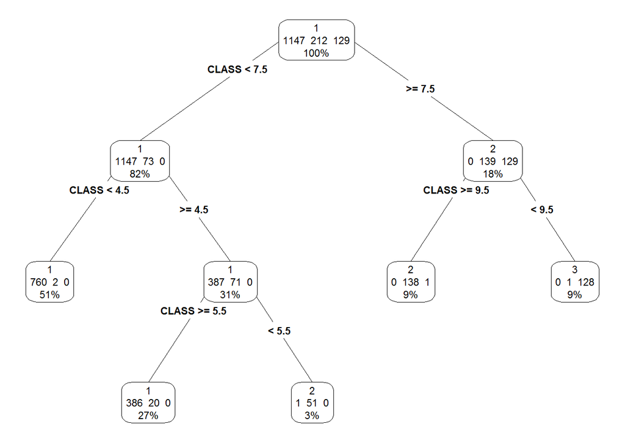

```r
NSP.rpart<-rpart(NSP_train$NSP ~ ., method="class", parms=list(split="gini"), data=NSP_train)
rpart.plot(NSP.rpart, type=4, extra=101, cex = 0.7)
```

#### Validation using test dataset

##### 1. Accuracy of the model is 98.59% - Overfitting due to the use of Class Variable ( Class - Morphological classifications by medical experties)

```r
actual <- NSP_test$NSP
NSP_predicted <- predict(NSP.rpart, newdata=NSP_test, type="class")
NSP_results.matrix <- confusionMatrix(NSP_predicted, actual, positive="yes")
print(NSP_results.matrix)
```

```
## Confusion Matrix and Statistics
##
##           Reference
## Prediction   1   2   3
##          1 506   7   0
##          2   2  76   0
##          3   0   0  47
##
## Overall Statistics
##
##                Accuracy : 0.9859
##                  95% CI : (0.9734, 0.9935)
##     No Information Rate : 0.7962
##     P-Value [Acc > NIR] : < 2.2e-16
##
##                   Kappa : 0.9583
##  Mcnemar's Test P-Value : NA
##
## Statistics by Class:
##
##                      Class: 1 Class: 2 Class: 3
## Sensitivity            0.9961   0.9157  1.00000
## Specificity            0.9462   0.9964  1.00000
## Pos Pred Value         0.9864   0.9744  1.00000
## Neg Pred Value         0.9840   0.9875  1.00000
## Prevalence             0.7962   0.1301  0.07367
## Detection Rate         0.7931   0.1191  0.07367
## Detection Prevalence   0.8041   0.1223  0.07367
## Balanced Accuracy      0.9711   0.9560  1.00000
```

##### Decision Tree using Gini Index Without Class Variable

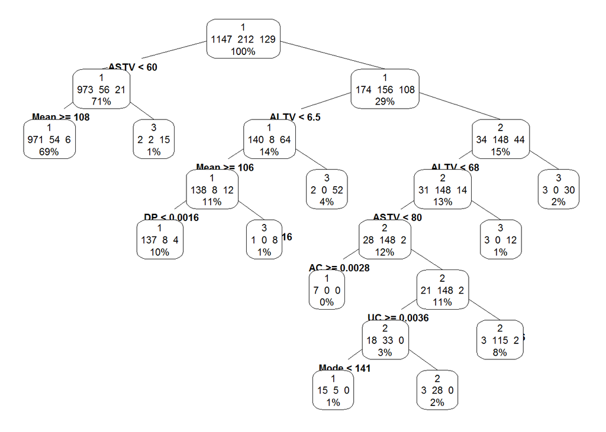

```r
NSP.rpart.class<-rpart(NSP_train_No.class$NSP ~ ., method="class", parms=list(split="gini"), data=NSP_train_No.class)
rpart.plot(NSP.rpart.class, type=4, extra=101, cex = 0.7)
```

#### Validation of model without Class Variable

##### 1. Accuracy of the model is to 92.3%,

##### 2. The previous model was overfitting due to Class variable (direct use of morphological classifications of medical experties)

##### 3. Hence, eliminated the class variable from Bagging and Randomforest Models in the further analysis

```r
actual.class <- NSP_test_No.class$NSP
NSP_predicted.class <- predict(NSP.rpart.class, newdata=NSP_test_No.class, type="class")
NSP_results.matrix.class <- confusionMatrix(NSP_predicted.class, actual.class, positive="yes")
print(NSP_results.matrix.class)
```

```
## Confusion Matrix and Statistics
##
##           Reference
## Prediction   1   2   3
##          1 496  32   4
##          2   6  51   1
##          3   6   0  42
##
## Overall Statistics
##
##                Accuracy : 0.9232
##                  95% CI : (0.8997, 0.9426)
##     No Information Rate : 0.7962
##     P-Value [Acc > NIR] : < 2.2e-16
##
##                   Kappa : 0.759
##  Mcnemar's Test P-Value : 0.0002498
##
## Statistics by Class:
##
##                      Class: 1 Class: 2 Class: 3
## Sensitivity            0.9764  0.61446  0.89362
## Specificity            0.7231  0.98739  0.98985
## Pos Pred Value         0.9323  0.87931  0.87500
## Neg Pred Value         0.8868  0.94483  0.99153
## Prevalence             0.7962  0.13009  0.07367
## Detection Rate         0.7774  0.07994  0.06583
## Detection Prevalence   0.8339  0.09091  0.07524
## Balanced Accuracy      0.8497  0.80092  0.94173
```

### 4. Bagging & Random Forest Approach to improve the model

#### Model using Bagging - Considering all predictors at each split

##### 1.OOB estimate of error rate: 6.45%

##### 2. ASTV, ALTV & Mean are predicted as most important Independent variable in predicting the output

```r
library(caret)
library(randomForest)
set.seed(123)


NSP.bag <- randomForest(NSP_train_No.class$NSP ~., data=NSP_train_No.class, mtry=13, na.action=na.omit, importance=TRUE)

print(NSP.bag) #note the "out of bag" (OOB) error rate.
```

```
##
## Call:
##  randomForest(formula = NSP_train_No.class$NSP ~ ., data = NSP_train_No.class,      mtry = 13, importance = TRUE, na.action = na.omit)
##                Type of random forest: classification
##                      Number of trees: 500
## No. of variables tried at each split: 13
##
##         OOB estimate of  error rate: 6.45%
## Confusion matrix:
##      1   2   3 class.error
## 1 1113  27   7  0.02964255
## 2   45 163   4  0.23113208
## 3    6   7 116  0.10077519
```

```r
importance(NSP.bag) #shows the importance of each variable. Variable importance is computed using the mean decrease in the Gini index.
```

```
##                  1         2          3 MeanDecreaseAccuracy
## AC       41.745721 31.000588 11.9300515            50.254270
## FM       14.086637 19.629289  2.5120297            24.047128
## UC       23.807947 24.935307 47.3979986            51.774241
## DL        2.616981  5.663919  0.9340838             6.719511
## DP       31.980966  2.278480 28.0459267            39.482456
## ASTV     62.023080 92.102766 78.5082141           123.820581
## ALTV     47.729229 66.376501 81.2177648           101.234735
## Width    23.094111 -6.166459  2.0518709            20.888937
## Min      22.252810 10.750988 13.8430089            27.720980
## Nmax     14.685824  3.249467  3.2602477            14.952636
## Mode     30.379026 13.633999 11.2569859            35.095684
## Mean     37.889078 19.922269 48.3670736            54.928406
## Variance 13.085046 -5.878401  6.6925231            12.027007
##          MeanDecreaseGini
## AC              28.317887
## FM              10.841505
## UC              28.124680
## DL               3.788737
## DP              34.903083
## ASTV           171.010810
## ALTV           125.313294
## Width           11.950276
## Min             22.138003
## Nmax            11.225409
## Mode            19.595257
## Mean            86.398081
## Variance         7.328624
```

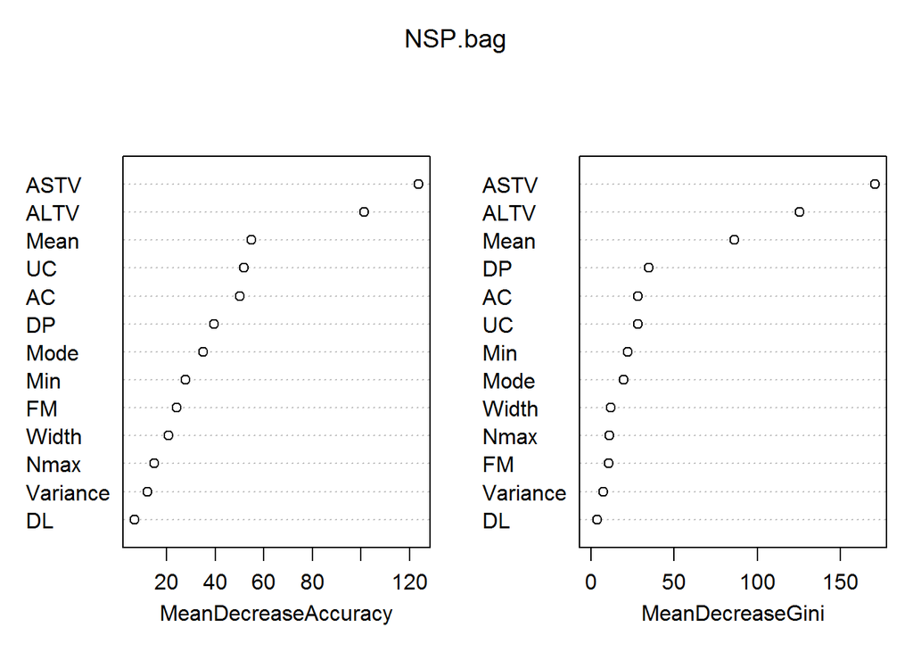

```r
varImpPlot(NSP.bag)
```

##### Validating the Bagging model using test dataset

```r
actual <- NSP_test_No.class$NSP
NSP_predicted.bag <- predict(NSP.bag, newdata=NSP_test_No.class, type="class")
NSP_results.matrix.bag <- confusionMatrix(NSP_predicted.bag, actual, positive="yes")
print(NSP_results.matrix.bag)
```

```
## Confusion Matrix and Statistics
##
##           Reference
## Prediction   1   2   3
##          1 495  19   3
##          2  10  62   1
##          3   3   2  43
##
## Overall Statistics
##
##                Accuracy : 0.9404
##                  95% CI : (0.9192, 0.9575)
##     No Information Rate : 0.7962
##     P-Value [Acc > NIR] : <2e-16
##
##                   Kappa : 0.8219
##  Mcnemar's Test P-Value : 0.3725
##
## Statistics by Class:
##
##                      Class: 1 Class: 2 Class: 3
## Sensitivity            0.9744  0.74699  0.91489
## Specificity            0.8308  0.98018  0.99154
## Pos Pred Value         0.9574  0.84932  0.89583
## Neg Pred Value         0.8926  0.96283  0.99322
## Prevalence             0.7962  0.13009  0.07367
## Detection Rate         0.7759  0.09718  0.06740
## Detection Prevalence   0.8103  0.11442  0.07524
## Balanced Accuracy      0.9026  0.86358  0.95322
```

#### Model using Random Forest Approach

##### 1.OOB estimate of error rate: 6.05%

##### 2. Again ASTV, ALTV & the Mean are predicted as most important Independent variable in predicting the output by Random forest method

```r
NSP.RForest <- randomForest(NSP_train_No.class$NSP ~.,data=NSP_train_No.class, mtry=3, ntree=600,na.action = na.omit, importance=TRUE) #default mtry = 3 and ntree= 500.
print(NSP.RForest) #shows OOB of model and confusion matrix
```

```
##
## Call:
##  randomForest(formula = NSP_train_No.class$NSP ~ ., data = NSP_train_No.class,      mtry = 3, ntree = 600, importance = TRUE, na.action = na.omit)
##                Type of random forest: classification
##                      Number of trees: 600
## No. of variables tried at each split: 3
##
##         OOB estimate of  error rate: 6.05%
## Confusion matrix:
##      1   2   3 class.error
## 1 1126  17   4  0.01830863
## 2   49 159   4  0.25000000
## 3    6  10 113  0.12403101
```

```r
importance(NSP.RForest) #shows the importance of each variable
```

```
##                 1         2         3 MeanDecreaseAccuracy
## AC       33.38218 29.115443 21.859118             39.66479
## FM       18.68979 17.767213  8.545860             24.73983
## UC       23.61595 24.903350 28.825034             36.94670
## DL       12.02673  8.345050  7.803084             15.04321
## DP       29.80512  8.832158 21.919148             33.34435
## ASTV     39.52834 51.171489 38.753491             57.59857
## ALTV     32.81145 39.988211 40.917739             52.25176
## Width    18.73671  5.879098 15.193358             22.83213
## Min      20.53950 15.912794 15.902581             27.49671
## Nmax     18.82080 -2.267492 11.012215             19.46955
## Mode     27.83754 19.752978 23.969667             39.56896
## Mean     32.47020 26.038856 35.027196             48.10296
## Variance 19.01609  5.423525 17.710245             24.21592
##          MeanDecreaseGini
## AC              35.836882
## FM              18.341808
## UC              36.819326
## DL               9.199933
## DP              34.927675
## ASTV           100.648656
## ALTV            93.010768
## Width           31.584939
## Min             34.970418
## Nmax            14.456632
## Mode            47.418180
## Mean            74.308790
## Variance        26.859041
```

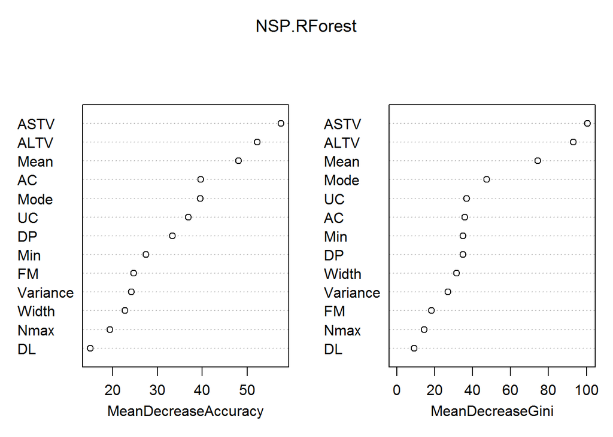

```r
varImpPlot(NSP.RForest) #plots the importance of each variable
```

#### Validating the Random Forest model using test dataset

##### 2. Random Forest turned out as the best model among rest of the models.

```r
actual <- NSP_test_No.class$NSP
NSP.RForest_predict<-predict(NSP.RForest, NSP_test_No.class ,type="response")
NSP.RForest_results.matrix <- confusionMatrix(NSP.RForest_predict, actual,positive="yes")
print(NSP.RForest_results.matrix)
```

```
## Confusion Matrix and Statistics
##
##           Reference
## Prediction   1   2   3
##          1 499  19   2
##          2   7  63   3
##          3   2   1  42
##
## Overall Statistics
##
##                Accuracy : 0.9467
##                  95% CI : (0.9263, 0.9628)
##     No Information Rate : 0.7962
##     P-Value [Acc > NIR] : < 2e-16
##
##                   Kappa : 0.839
##  Mcnemar's Test P-Value : 0.08816
##
## Statistics by Class:
##
##                      Class: 1 Class: 2 Class: 3
## Sensitivity            0.9823  0.75904  0.89362
## Specificity            0.8385  0.98198  0.99492
## Pos Pred Value         0.9596  0.86301  0.93333
## Neg Pred Value         0.9237  0.96460  0.99157
## Prevalence             0.7962  0.13009  0.07367
## Detection Rate         0.7821  0.09875  0.06583
## Detection Prevalence   0.8150  0.11442  0.07053
## Balanced Accuracy      0.9104  0.87051  0.94427
```

```r
print(NSP_results.matrix.bag)
```

```
## Confusion Matrix and Statistics
##
##           Reference
## Prediction   1   2   3
##          1 495  19   3
##          2  10  62   1
##          3   3   2  43
##
## Overall Statistics
##
##                Accuracy : 0.9404
##                  95% CI : (0.9192, 0.9575)
##     No Information Rate : 0.7962
##     P-Value [Acc > NIR] : <2e-16
##
##                   Kappa : 0.8219
##  Mcnemar's Test P-Value : 0.3725
##
## Statistics by Class:
##
##                      Class: 1 Class: 2 Class: 3
## Sensitivity            0.9744  0.74699  0.91489
## Specificity            0.8308  0.98018  0.99154
## Pos Pred Value         0.9574  0.84932  0.89583
## Neg Pred Value         0.8926  0.96283  0.99322
## Prevalence             0.7962  0.13009  0.07367
## Detection Rate         0.7759  0.09718  0.06740
## Detection Prevalence   0.8103  0.11442  0.07524
## Balanced Accuracy      0.9026  0.86358  0.95322
```

## FOR - Insights

The Cardiotocogrphy dataset contains the records of 2126 samples of medical recording contain fetal Cardiotocograph (CTGs) records with the details as show below.

1. LB Baseline value
2. AC accelerations
3. FM fetal movement
4. UC uterine contractions
5. DL light decelerations
6. DS severe decelerations
7. DP Prolonged decelerations
8. ASTV percentage of time with abnormal short term variability
9. MSTV mean value of short term variability
10. ALTV percentage of time with abnormal long term variability
11. MLTV mean value of long term variability
12. Width histogram width
13. Min low freq. of the histogram
14. Max high freq. of the histogram
15. Nmax number of histogram peaks
16. Nzeros number of histogram zeros
17. Mode histogram mode
18. Mean histogram mean
19. Median histogram median
20. Variance histogram variance
21. Tendency histogram tendency: -1=left asymmetric; 0=symmetric; 1=right asymmetric

Using these variables modeling has been done to predict the fetal status as (N=normal; S=suspect; P=pathologic) or morphologic patterns ( 1 to 10) This predictions could help us taking further steps, 1. Precautionary measures 2. Decisions on medical care etc.

### FACTS

According to the data set: 1. We divided the 2126 medical records Cardio graphic data into 2 datasets with 70% sample size for building the model and 30% sample size for testing and validation. 2. Our goal is to create a model for NSP Classification using training data set (Subset of database) and Validating the model using Testing dataset (another subset). This could help in predicting the fetal status.

### OPTIONS

We have developed multiple prediction algorithms, which could help us in classifying the fetal status, most of the models could help us classifying up to 92% accurately.

### RECOMMENDATIONS

1. Random Forest model could be used to classify the NSP categories with the accuracy 94.67%, which is highest among all the models.
2. Bagging model can also be used for confirming the result, even this model is performing the equally good with almost 94.04% accuracy.